# PA1_template

# Imputing missing values

1. Calculate and report the total number of missing values in the dataset (i.e. the total number of rows with NAs)

```r
sum(is.na(data))
```

```
## [1] 2304
```

2. Devise a strategy for filling in all of the missing values in the dataset.

The strategy is to use the mean tfor that 5-minute interval

3. Create a new dataset that is equal to the original dataset but with the missing data filled in

```r
data_aggregate_interval_mean<-aggregate(steps ~ interval, data, mean)
dataComplete<-merge(data,data_aggregate_interval_mean,by="interval",suffix=c("",".y"))
valNA<-is.na(dataComplete$steps)
dataComplete$steps[valNA]<-dataComplete$steps.y[valNA]
dataComplete<-dataComplete[,c(1:3)]
```

4. Make a histogram of the total number of steps taken each day

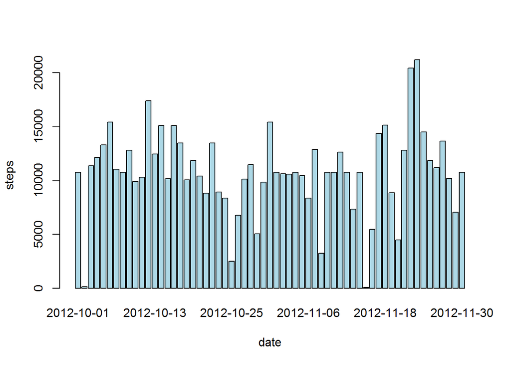

```r
dataComplete_aggregate_date<-aggregate(steps ~ date, dataComplete, sum)
barplot(dataComplete_aggregate_date$steps, names.arg = dataComplete_aggregate_date$date, xlab = "date", ylab = "steps",col = "lightblue")
```

5. Calculate and report the mean and median total number of steps taken per day.

```r
mean(dataComplete_aggregate_date$steps)
```

```
## [1] 10766.19
```

```r
median(dataComplete_aggregate_date$steps)
```

```
## [1] 10766.19
```

6. Do these values differ from the estimates from the first part of the assignment?

The inpact on mean is obviously null cause we have used mean to estimate missing data; median tends to become equal to the average.

7. What is the impact of imputing missing data on the estimates of the total daily number of steps?

We calculate % value

```r
S1<-sum(dataComplete_aggregate_date$steps)
S2<-sum(data_aggregate_date$steps)
(S1-S2)/S1*100
```

```
## [1] 13.11475
```